# Densidad del aire

```r
# install.packages("data.table")
## install.packages("ggplot2")
# library(data.table)
# library(ggplot2)
library(hms) # Para tratar con tiempos en formato hora:minuto:segundos
library(dplyr) # Para facilitar la manipulación y operaciones con dataframes
library(ggpubr)
```

En este cuaderno de R se busca implementar una estimación de la densidad del aire con su incertidumbre en el laboratorio de balanzas del DMQ del LCM. Para esto se cuentan con datos de cuatro años de las condiciones ambientales del laboratorio.

Deberá implementar la estimación de la densidad del aire por medio de la fórmula CIPM-2007 que se encuentra en el artículo *Revised formula for the density of moist air (CIPM-2007)* de A Picard, R S Davis, M Gläser y K Fujii del $2008$, este se puede visitar en https://www.nist.gov/system/files/documents/calibrations/CIPM-2007.pdf.

Para utilizar una constante de los gases ideales más actualizada puede tomarla de [https://physics.nist.gov/cgi-bin/cuu/Value?r|search_for=R](https://physics.nist.gov/cgi-bin/cuu/Value?r%7Csearch_for=R), pues es el valor más actualizado de acuerdo a las definiciones nuevas de las magnitudes.

Inicialmente, deberá realizar un análisis exploratorio de las magnitudes de interés: temperatura ambiental, presión atmosférica y humedad relativa.

- Realice una discriminación de datos diurnos (8 am a 4 pm) y nocturnos para que el estudio sea más completo.
- Descarte los datos atípicos.
- Analice tendencias, si las hubiera, en las magnitudes de influencia.

Seguidamente, deberá elaborar las funciones que permiten realizar los cálculos de los diversos parámetros que se utilizan en la fórmula del CIPM-2007, para lo cual deberá ser cuidadoso con las unidades, puesto que algunos utilizan la presión en Pa y otros en hPa, así como la temperatura en grados Celsius o en Kelvin.

Para agregar una celda de código nueva utilice `Ctrl+Alt+I` y automáticamente se genera el *chunk* para escribir código R.

**Utilice los espacios entre *chunks* para comentar los análisis realizados, explicar las funciones utilizadas y explicar las observaciones encontradas**

# Carga de datos

Una forma sencilla de cargar los datos es por medio de un `for` que itere sobre listas de directorios o archivos. Pero puede investigar formas más ágiles de hacer este procedimiento (`do.call` y `lapply`). La cantidad de datos ronda casi el millón de datos, por lo que se espera que una vez cargados la visualización sea un tanto lenta.

```r
filedir="Datos/CondicionesAmbientalesBalanzas" # directorio de datos
años=list.dirs(path = filedir, full.names = TRUE, recursive = TRUE)[2:5] # lista de directorios
filedir="Datos/CondicionesAmbientalesBalanzas" # directorio de datos
años=list.dirs(path = filedir, full.names = TRUE, recursive = TRUE)[2:5] # lista de directorios

for (año in 1:4) {
  filesAnuales=list.files(path = años[año], full.names = TRUE, recursive = TRUE)
    for (file in 1:length(filesAnuales)){
      if (año==1 & file==1){
        df = read.csv(file = filesAnuales[1], header=FALSE, sep="",dec=".", fill = TRUE, fileEncoding="latin1")
      }
      else{
        df_i = read.csv(file = filesAnuales[file], header=FALSE, sep="",dec=".", fill = TRUE, fileEncoding="latin1")
        df <- rbind(df,df_i)
      }
    }
}
colnames(df) <- c("Fecha","Hora","Temperatura","°C","Humedad","%","Presión","hPa","Densidad","g/cm3","x","y","z")


df$Hora <- as_hms(df$Hora)
df = mutate(df, Horario = if_else(Hora > as_hms("7:59:59") & Hora < as_hms("16:00:00"), "Diurno", "Nocturno"))
```

# Análisis exploratorio de las magnitudes de interés

Aplique las técnicas más convenientes según su criterio de analista a los datos de las magnitudes de interés.

```r
# Utilice las herramientas que hasta el momento ha aprendido en el curso para analizar la temperatura ambiental, la presión atmosférica y la humedad relativa.
```

# Analisis de Magnitudes por Año

```r
#Creamos las variables de los datos anuales

df_2019<- df %>% filter(grepl("9$", Fecha))
df_2020<- df %>% filter(grepl("0$", Fecha))
df_2021<- df %>% filter(grepl("1$", Fecha))
df_2022<- df %>% filter(grepl("2$", Fecha))
```

```
#> summary(subset(df_2019, select = c("Temperatura","Humedad","Presión","Densidad")))
```

# Funciones para el cálculo de la densidad del aire

Para calcular la densidad del aire utilizando la fórmula del CIPM 2007 es necesario tener sumo cuidado con las unidades. Puesto que para calcular algunos parámetros las fórmulas utilizan la temperatura en ºC o en K, la presión atmosférica en hPa o en Pa y la humedad relativa como un valor entre 0 y 1 o como un valor entre 0 y 100.

Puede realizar los cambios que considere pertinentes

```r
Psv=function(t){
  # Función que calcula la presión de vapor de saturación siguiendo la fórmula que se presenta en el artículo de referencia.
  #Input:
  #-------------
  #t: temperatura en °C.

  #Output:
  #-------------
  #Psv: valor de la presión de vapor de saturación en hPa.

  A = 1.2378847 * 10^(-5) #K^-2
  B = -1.9121316 * 10^(-2) #K^-1
  C = 33.93711047
  D = -6.3431645 * 10^(3) #K
  Tk = 273.15 + t #K
  Psv = 1 * exp(A*(Tk)^2 + B*Tk + C + D/Tk)
  return(Psv/100)
}
```

```r
f=function(t,P){
  # Función que calcula el factor de fugasidad siguiendo la ecuación de la referencia.

  # Input:
  # --------------
  # P: presión en Pa.
  # t: temperatura en °C.

  # Output:
  # --------------
  # f: Valor del coeficiente de fugacidad.

  alpha = 1.00062
  beta = 3.14 * 10^(-8) #Pa^(-1)
  gamma = 5.6 * 10^(-7) #K^(-2)

  f = alpha + beta*P + gamma*(t^2)

  return(f)
}
```

```r
xv=function(t,P,h){
  # Función que calcula la fracción molar de vapor de agua siguiendo el artículo de referencia.

  # Input:
  # ---------------
  # h: humedad relativa como un valor entre 0 y 1
  # P: presión atmosférica en Pa.
  # t: Temperatura en °C.

  # Output:
  # ---------------
  # xv: Valor de la fracción molar de vapor de agua.
  f = f(t,P)
  Psv = Psv(t)
  xv = (h*f*Psv)/(P)
  return(xv)
}
```

```r
Z=function(t,P,h){
  # Función que calcula el factor de compresibilidad con la ecuación del artículo de referencia.

  # Input:
  # --------------
  # P: Presión atmosférica en Pa.
  # h: Humedad relativa como un valor entre 0 y 1.
  # t: Temperatura en °C.

  # Output:
  # ---------------
  # Z: factor de compresibilidad.

  a0 = 1.58123 * 10^(-6) #KPa^(-1)
  a1 = -2.9331 * 10^(-8) #Pa^(-1)
  a2 = 1.1043 * 10^(-10) #K^(-1)Pa^(-1)
  b0 = 5.707 * 10^(-6) #KPa^(-1)
  b1 = -2.051 * 10^(-8) #Pa^(-1)
  c0 = 1.9898 * 10^(-4) #KPa^(-1)
  c1 = -2.376 * 10^(-6) #Pa^(-1)
  d = 1.83 * 10^(-11) #K^(2)Pa^(-2)
  e = -0.765 * 10^(-8) #K^(2)Pa^(-2)

  xv = xv(t,P,h)
  Tk = 273.15 + t
  Z = 1 - P*(a0 + a1*t + a2*(t^2) + (b0 + b1*t)*xv + (c0 + c1*t)*(xv^2))/(Tk) + P^2*(d + e*(xv^2))/(Tk^2)

  return(Z)
}
```

```r
DensidadCIPM=function(t,P,h){
  # Función que calcula la densidad del aire a partir de la ecuación del artículo de referencia.

  # Input:
  # --------------
  # P: Presión atmosférica en Pa.
  # h: Humedad relativa como un valor entre 0 y 1.
  # t: Temperatura en °C.

  # Output:
  # --------------
  # rho: densidad del aire en kg/m^3.

  Ma = 28.96546 * 10^(-3) #kg mol^(-1)
  Mv = 18.01528 * 10^(-3) #kg mol^(-1)
  R = 8.314462618 #J mol^(-1) K^(-1)
  Tk = 273.15 + t #K
  Z = Z(t,P,h)
  xv = xv(t,P,h)

  rho = (P*Ma)/(Z*R*Tk) * (1 - xv*(1 - (Mv/Ma)))
  return(rho)
}
```

```r
# Calcule las densidades
DensidadDf=function(t,P_hpa,h_100){
  # Función que calcula la densidad del aire a partir de la ecuación del artículo de referencia, considerando unidades usadas en el dataframe.

  # Input:
  # --------------
  # P_hpa: Presión atmosférica en hPa.
  # h_100: Humedad relativa como un valor entre 0 y 100.
  # t: Temperatura en °C.

  # Output:
  # --------------
  # rho: densidad del aire en g/cm^3.

  P = P_hpa * 100 #Presión en Pa
  h = h_100 / 100 #Humedad relativa como valor entre 0 y 1
  rho = DensidadCIPM(t,P,h) / 1000 #Densidad del aire en g/cm^3
  return(rho)
}
densidades=DensidadDf(df$Temperatura,df$Presión,df$Humedad)
```

Aplicación de las funciones:

```r
func_results <- data.frame(Presión_de_Saturación = Psv(df$Temperatura), Fugasidad = f(df$Temperatura,df$Presión), Fracción_Molar_VapAgua = xv(df$Temperatura,df$Presión,df$Humedad), Fact_Compresibilidad = Z(df$Temperatura,df$Presión,df$Humedad))
```

# Análisis exploratorio de las densidades calculados

Análisis por horario (diurno/nocturno):

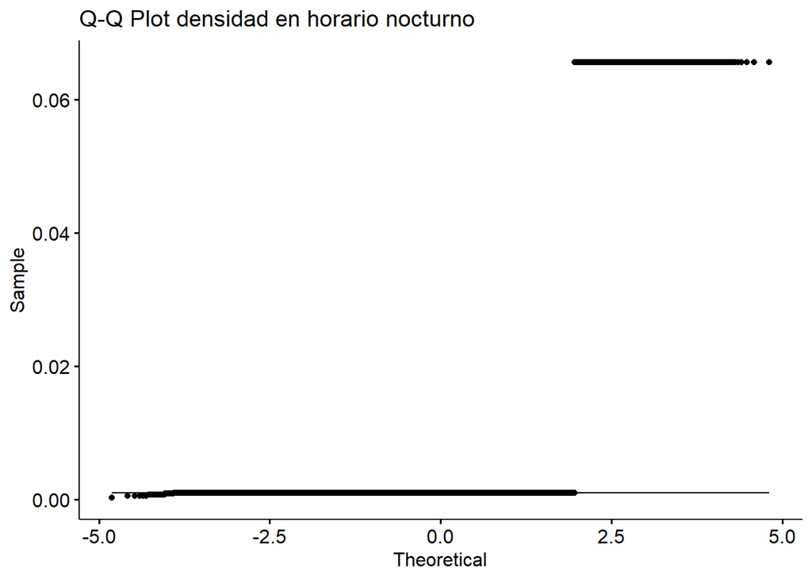

```r
df_noc <- filter(df,Horario == 'Nocturno')
df_dia <- filter(df,Horario == 'Diurno')
ggqqplot(df_noc$Densidad, title = 'Q-Q Plot densidad en horario nocturno')
```

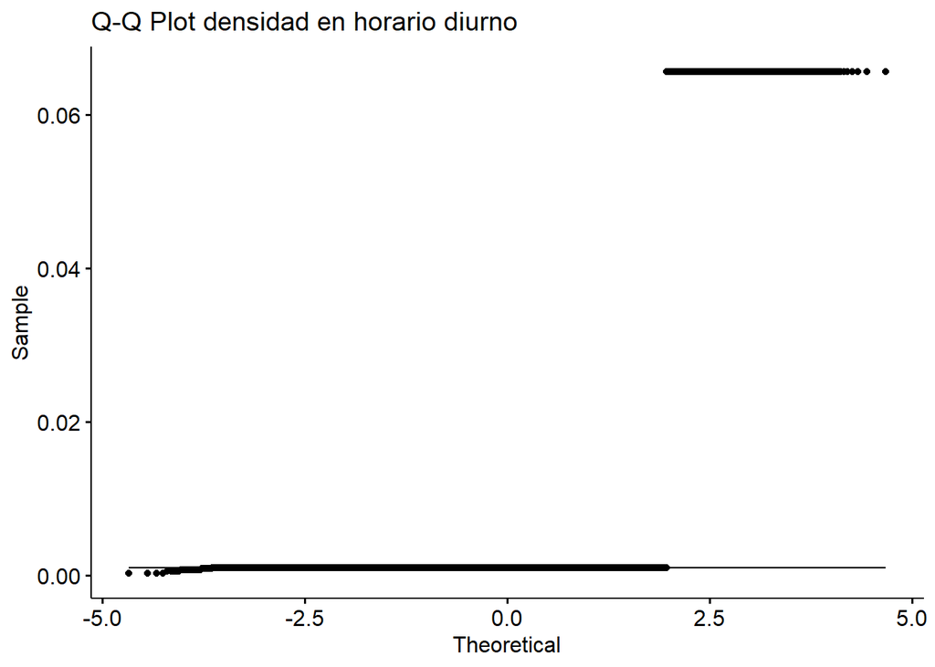

```r
ggqqplot(df_dia$Densidad, title = 'Q-Q Plot densidad en horario diurno')
```

Los gráficos anteriores muestran como en ambos casos, existen valores que se alejan en gran medida de la muestra general. Valores mayores a 0,06 g/cm^3 que no tienen sentido en el contexto actual. Según la linea de normalidad, estos datos son los que menos se ajustan también a la normalidad de la muestra. Por tanto, los mismos pueden considerarse datos atípicos y deben ser eliminados.

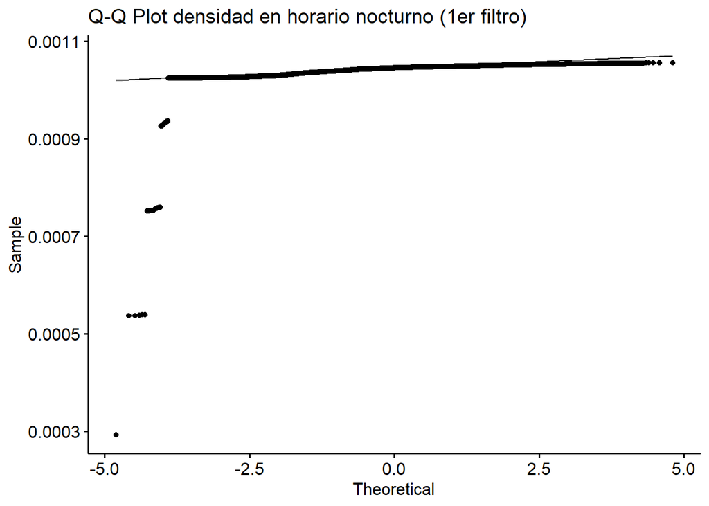

```r
df_noc1 <- filter(df_noc,Densidad<0.06)
df_dia1 <- filter(df_dia,Densidad<0.06)
ggqqplot(df_noc1$Densidad, title = 'Q-Q Plot densidad en horario nocturno (1er filtro)')
```

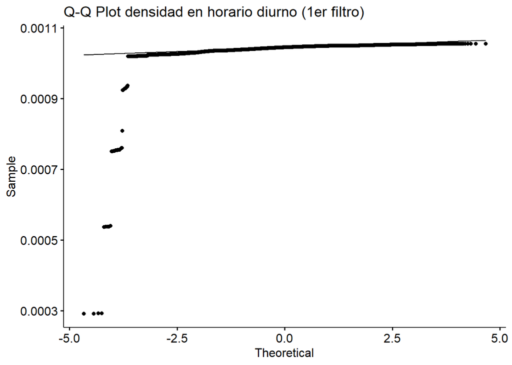

```r
ggqqplot(df_dia1$Densidad, title = 'Q-Q Plot densidad en horario diurno (1er filtro)')
```

Los valores menores a 0.001 también pueden descartarse ya que de igual forma se alejan de la tendencia general del resto de datos y corresponden a valores que por lo general no serían comunes de medir en el espacio experimental donde se determinaron las condiciones ambientales.

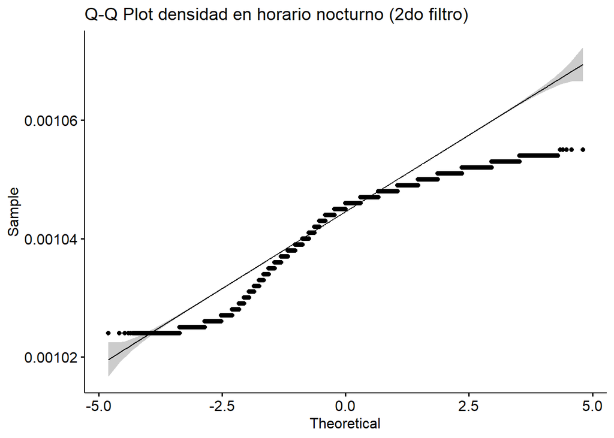

```r
df_noc2 <- filter(df_noc1,Densidad>0.001)
df_dia2 <- filter(df_dia1,Densidad>0.001)
ggqqplot(df_noc2$Densidad, title = 'Q-Q Plot densidad en horario nocturno (2do filtro)')
```

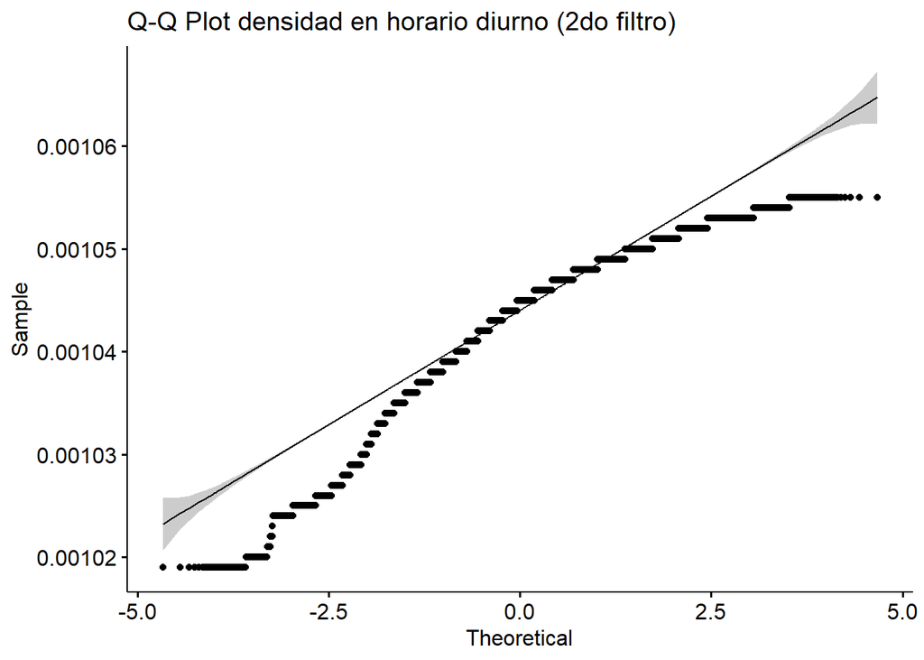

```r
ggqqplot(df_dia2$Densidad, title = 'Q-Q Plot densidad en horario diurno (2do filtro)')
```

Puede notarse también que, a pesar de la eliminación de los valores anómalos, los valores de densidad no siguen una distribución normal. Para conocer como se distribuyen estos datos, se elaborará un histograma.

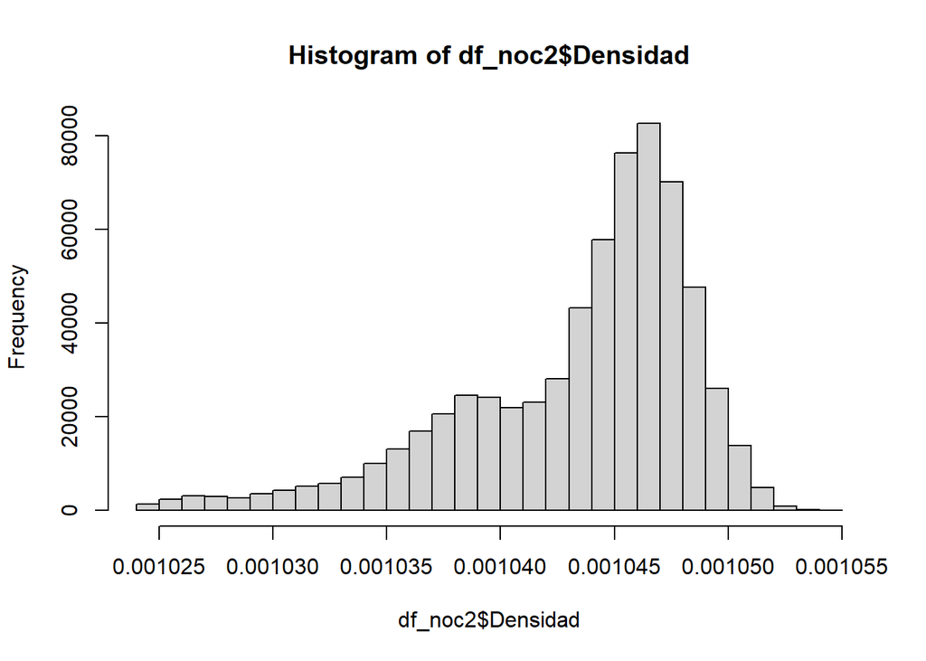

```r
hist(df_noc2$Densidad,breaks = 40)
```

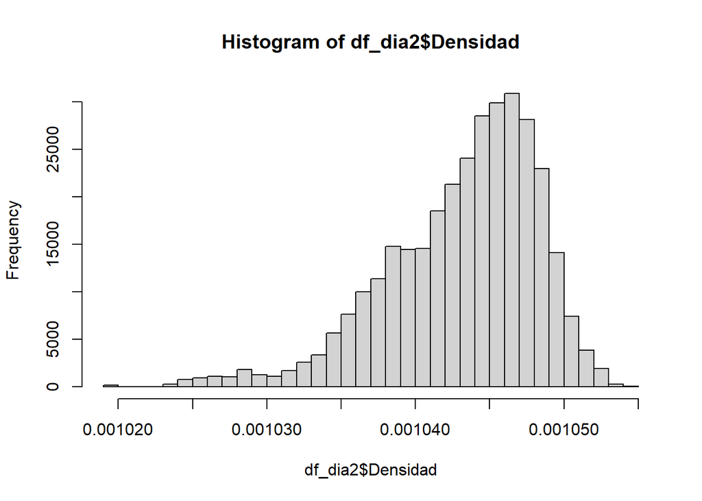

```r
hist(df_dia2$Densidad, breaks = 50)
```

```r
summary(df_noc2$Densidad)
```

```
##     Min.  1st Qu.   Median     Mean  3rd Qu.     Max.
## 0.001024 0.001041 0.001046 0.001044 0.001048 0.001055
```

```r
summary(df_dia2$Densidad)
```

```
##     Min.  1st Qu.   Median     Mean  3rd Qu.     Max.
## 0.001019 0.001041 0.001045 0.001044 0.001047 0.001055
```

De lo anterior se puede observar que: (1) La forma de los histogramas claramente no siguen la forma de la distribución normal, tal y como se esperaba por los gráficos Q-Q, (2) El perfil que siguen las columnas de los histogramas presenta, aparentemente, dos máximos locales en aproximadamente 0.001039 g/cm^3 (moda menor) y 0.001046 g/cm^3 para el caso nocturno y para el caso diurno en 0.001037 g/cm^3 (moda menor, mas sutil que en el caso nocturno) y 0.001047 g/cm^3 (moda mayor), (3) Ambos grupos tienen medias y máximos iguales y valores muy similares para sus medianas y cuartiles, (4) Sus distribuciones no son simétricas relativo a sus medias o medianas y tienden a tener una oblicuidad (skewness) negativa, (5) La mayoría de los datos se distribuyen mayormente alrededor de las modas de las distribuciones con una kurtoris positiva.

```r
wilcox.test(df_noc2$Densidad,df_dia2$Densidad)
```

```
##
##  Wilcoxon rank sum test with continuity correction
##
## data:  df_noc2$Densidad and df_dia2$Densidad
## W = 1.1067e+11, p-value < 2.2e-16
## alternative hypothesis: true location shift is not equal to 0
```